# Project Report

- Sentimental Analysis on Amazon Review(Music Instruments)

### By:

- Ajay Ramesh
- MSCS | IIT Chicago
- CS595

### Reference

- Active Learning with Rationales for Text Classification
  - Manali Sharma, Di Zhuang and Mustafa Bilgic
  - http://www.cs.iit.edu/~ml/pdfs/sharma-naaclhlt15.pdf

#### Date - 12/3/2017

dataset - http://jmcauley.ucsd.edu/data/amazon/

#### Musical Instruments Prodcut Review is used.

### Experiment Setup Overview

- Derived a small Dataset from 10 Reviews which has all kind of reviews(5, 4, 3, 2, 1 stars)
- Created a seperate training and test dataset. Test is not used in any training.
- Human Labelled from My friend **Hemanth and Bashyeam. - Thank you Guys** .50 Documents are carefully labelled.
- Everything is exported into csv. That is used in this experiment.

## Section 1: Dataset Description

I used the Amazon review dataset on Musical Instuments, which is available in http://jmcauley.ucsd.edu/data/amazon/. The small version is present in data folder. It has below columns with human labelled rationales

|  | Train-Columns |
| --- | --- |
| 0 | _id |
| 1 | asin |
| 2 | cleaned_review_text |
| 3 | helpful.0 |
| 4 | helpful.1 |
| 5 | human_labelled |
| 6 | keywords |
| 7 | labelled |
| 8 | load_to_db |
| 9 | neg_doc |
| 10 | overall |
| 11 | rationales |
| 12 | rationals.0 |
| 13 | rationals.1 |
| 14 | rationals.2 |
| 15 | rationals.3 |
| 16 | rationals.4 |
| 17 | rationals.5 |
| 18 | rationals.6 |
| 19 | rationals.7 |
| 20 | reviewText |

```python
pd.DataFrame(test.columns, columns=['Test-Columns'])
```

|  | Test-Columns |
| --- | --- |
| 0 | asin |
| 1 | overall |
| 2 | reviewText |

```python
test.head()
```

|  | asin | overall | reviewText |
| --- | --- | --- | --- |
| 0 | B0002E37MM | 1 | I bought this hoping to use as intended, angle... |
| 1 | B0002E2Z8Y | 1 | I know many people love the design, but I find... |
| 2 | B0002E2KPC | 1 | This is an update to my original review becaus... |
| 3 | B0002E1O2M | 1 | I bought a set as they were recommended to get... |
| 4 | B0002DV7U2 | 1 | ...for something, but not a guitar. Wasn't su... |

### Section 2: Model Fit Basic

I want to see how it behaves without active learning, so I tested across **Logistic Regression and BNB**. I choose Logistic Regression for active learning part

#### BernoulliNB

- Accuarcy - 81.939163498098855 %
- AUC - 100 %

#### C = 0.001

- Accuarcy - 65.20 %
- AUC - 61 %

#### C = 1

- Accuarcy - 99.61 %
- AUC - 100 %

### Top 10 Feature absolute weights using Logistic Regression:

All words does not make sense The words which doesnt not make sense to me are-

- by
- almost
- midi
- thick

|  | 0 | 1 |
| --- | --- | --- |
| 0 | midi | 1.189383 |
| 1 | fine | 1.072322 |
| 2 | noticed | 1.045061 |
| 3 | came | 0.970896 |
| 4 | thick | 0.925214 |
| 5 | just | 0.923685 |
| 6 | almost | 0.870380 |
| 7 | equipment | 0.860073 |
| 8 | noisy | 0.859717 |
| 9 | by | 0.837260 |

## Section 3: Active Learning

Top 10 Positive Words

```python
pd.DataFrame(pos_words[:10])
```

|  | 0 |
| --- | --- |
| 32 | amazon |
| 683 | pop |
| 365 | good |
| 694 | pretty |
| 748 | reviews |
| 278 | especially |
| 690 | practice |
| 206 | cutter |
| 1006 | with |
| 934 | try |

Top 10 negative Words

```python
pd.DataFrame(neg_words[:10])
```

|  | 0 |
| --- | --- |
| 961 | useless |
| 545 | midi |
| 190 | control |
| 540 | mic |
| 558 | monster |
| 543 | mics |
| 588 | noisy |
| 984 | week |
| 618 | opinion |
| 724 | read |

### Active Learning using Tandem Learning

In which we mark top words from chi-square to rationale

```python
r = 1
o = 0.01
```

[figure not shown]

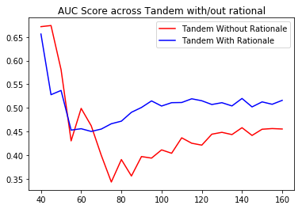

```python
plt.title("AUC Score across Tandem with/out rational")
plt.plot(x_ax, t_no_rational[1],  'r-',label="Tandem Without Rationale")
plt.plot(x_ax, t_with_rational[1],  'b-',label="Tandem With Rationale")
plt.legend()
```

#### Human Labelled Preview

"Not much to write about here, but it does exactly what it's supposed to. filters out the pop sounds. now my recordings are much more crisp. it is one of the lowest prices pop filters on amazon so might as well buy it, they honestly work the same despite their pricing,"

```python
L_docs.head()
```

|  | ReviewText | Rationales | Y |
| --- | --- | --- | --- |
| 0 | Not much to write about here, but it does exac... | exactly,crisp,lowest,,,,, | False |
| 1 | The product does exactly as it should and is q... | does,affordable,,,,,, | False |
| 2 | The primary job of this device is to block the... | no,noticeable,reduction,secure,,,, | False |
| 3 | Nice windscreen protects my MXL mic and preven... | prevents,pops,,,,,, | False |
| 4 | This pop filter is great. It looks and perform... | great,looks,performs,eliminate,pops,,, | False |

## Section 5: Active Learning with Rationale

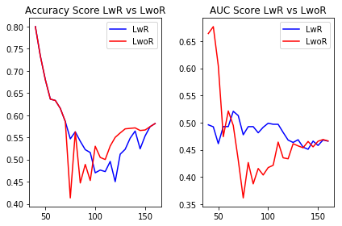

# Conclusion: Transparency Overview

```python
FW
```

|  | Tandem (rational, artificial labeler) | Weights | Tandem(no rational) | Weights | LwR(Human Labelled) | Weights | LwoR | Weights |
| --- | --- | --- | --- | --- | --- | --- | --- | --- |
| 0 | and | 0.035263 | on | 0.011774 | great | 0.002962 | on | 0.011758 |
| 1 | by | 0.025491 | to | 0.008361 | good | 0.002933 | to | 0.008355 |
| 2 | with | 0.025165 | get | 0.008341 | quality | 0.001477 | get | 0.008337 |
| 3 | opinion | 0.018606 | have | 0.008263 | well | 0.001457 | have | 0.008261 |
| 4 | its | 0.015229 | can | 0.008082 | cables | 0.001030 | in | 0.007907 |
| 5 | good | 0.014789 | in | 0.007987 | higher | 0.001015 | for | 0.007708 |
| 6 | control | 0.010322 | for | 0.007722 | horrible | 0.001010 | and | 0.007377 |
| 7 | has | 0.008529 | and | 0.007383 | doesnt | 0.001005 | can | 0.006902 |
| 8 | there | 0.008044 | other | 0.006749 | looks | 0.001004 | other | 0.006714 |
| 9 | sm | 0.007816 | little | 0.006409 | recommended | 0.000995 | little | 0.006414 |

### Future works

- Logistic Regression is choosed just for simplicity. But in future try other models.
- Scale the dataset. Here I Used a small version of dataset
- Collect Rationales more using Uncertainity Sampling
- Extend the Web-APP UI to hold deletion.
- Try Learning with Explanation